# Data Captson- Project

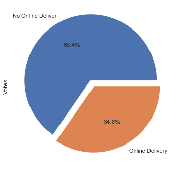

```python
Number_of_votes.plot(kind= 'pie', figsize=(10,6), labels = Votes_Legend, explode= (0.1,0), autopct='%1.1f%%')

plt.show()
```

```python
cuisines_split = df['Cuisines'].apply(lambda x: pd.Series(x.split(',')))
cuisines_split.columns=['Cuisine 1','Cuisine 2','Cuisine 3','Cuisine 4','Cuisine 5','Cuisine 6','Cuisine 7','Cuisine 8']
cuisines_split.head()
```

|  | Cuisine 1 | Cuisine 2 | Cuisine 3 | Cuisine 4 | Cuisine 5 | Cuisine 6 | Cuisine 7 | Cuisine 8 |
| --- | --- | --- | --- | --- | --- | --- | --- | --- |
| 0 | Italian | Continental | NaN | NaN | NaN | NaN | NaN | NaN |
| 1 | Asian | Indonesian | Western | NaN | NaN | NaN | NaN | NaN |
| 2 | Sushi | Japanese | NaN | NaN | NaN | NaN | NaN | NaN |
| 3 | Japanese | NaN | NaN | NaN | NaN | NaN | NaN | NaN |
| 4 | French | Western | NaN | NaN | NaN | NaN | NaN | NaN |

```python
Cuisine1_count=pd.DataFrame(cuisines_split["Cuisine 1"].value_counts()).reset_index()
Cuisine1_count=Cuisine1_count.rename(columns={"index": "Cuisines", "Cuisine 1": "Counts"})
Cuisine1_count.head(10)
```

|  | Cuisines | Counts |
| --- | --- | --- |
| 0 | North Indian | 2991 |
| 1 | Chinese | 855 |
| 2 | Fast Food | 672 |
| 3 | Bakery | 621 |
| 4 | Cafe | 617 |
| 5 | American | 278 |
| 6 | South Indian | 262 |
| 7 | Mithai | 246 |
| 8 | Street Food | 236 |
| 9 | Continental | 235 |

```python
cuisines_split = df['Cuisines'].apply(lambda x: pd.Series(x.split(',')))
cuisines_split.columns=['Cuisine 1','Cuisine 2','Cuisine 3','Cuisine 4','Cuisine 5','Cuisine 6','Cuisine 7','Cuisine 8']
cuisines_split.head()
```

|  | Cuisine 1 | Cuisine 2 | Cuisine 3 | Cuisine 4 | Cuisine 5 | Cuisine 6 | Cuisine 7 | Cuisine 8 |
| --- | --- | --- | --- | --- | --- | --- | --- | --- |
| 0 | Italian | Continental | NaN | NaN | NaN | NaN | NaN | NaN |
| 1 | Asian | Indonesian | Western | NaN | NaN | NaN | NaN | NaN |
| 2 | Sushi | Japanese | NaN | NaN | NaN | NaN | NaN | NaN |
| 3 | Japanese | NaN | NaN | NaN | NaN | NaN | NaN | NaN |
| 4 | French | Western | NaN | NaN | NaN | NaN | NaN | NaN |

```python
Cuisine2_count=pd.DataFrame(cuisines_split["Cuisine 2"].value_counts()).reset_index()
Cuisine2_count=Cuisine2_count.rename(columns={"index": "Cuisines", "Cuisine 2": "Counts"})
Cuisine2_count.head(10)
```

|  | Cuisines | Counts |
| --- | --- | --- |
| 0 | Chinese | 1156 |
| 1 | Fast Food | 820 |
| 2 | North Indian | 687 |
| 3 | Mughlai | 635 |
| 4 | Desserts | 407 |
| 5 | Continental | 244 |
| 6 | Italian | 240 |
| 7 | South Indian | 219 |
| 8 | Street Food | 216 |
| 9 | Thai | 110 |

```python
Cuisine3_count=pd.DataFrame(cuisines_split["Cuisine 3"].value_counts()).reset_index()
Cuisine3_count=Cuisine3_count.rename(columns={"index": "Cuisines", "Cuisine 3": "Counts"})
Cuisine3_count.head(10)
```

|  | Cuisines | Counts |
| --- | --- | --- |
| 0 | Chinese | 594 |
| 1 | Fast Food | 385 |
| 2 | Continental | 193 |
| 3 | North Indian | 191 |
| 4 | Italian | 189 |
| 5 | Mughlai | 124 |
| 6 | South Indian | 123 |
| 7 | Salad | 70 |
| 8 | Asian | 64 |
| 9 | Thai | 50 |

```python
Cuisine4_count=pd.DataFrame(cuisines_split["Cuisine 4"].value_counts()).reset_index()
Cuisine4_count=Cuisine4_count.rename(columns={"index": "Cuisines", "Cuisine 4": "Counts"})
Cuisine4_count.head(10)
```

|  | Cuisines | Counts |
| --- | --- | --- |
| 0 | Italian | 84 |
| 1 | Chinese | 81 |
| 2 | Fast Food | 77 |
| 3 | Healthy Food | 67 |
| 4 | North Indian | 65 |
| 5 | Street Food | 59 |
| 6 | Continental | 50 |
| 7 | Asian | 31 |
| 8 | Mithai | 26 |
| 9 | South Indian | 25 |

```python
Cuisine5_count=pd.DataFrame(cuisines_split["Cuisine 5"].value_counts()).reset_index()
Cuisine5_count=Cuisine5_count.rename(columns={"index": "Cuisines", "Cuisine 5": "Counts"})
Cuisine5_count.head(10)
```

|  | Cuisines | Counts |
| --- | --- | --- |
| 0 | Chinese | 41 |
| 1 | Fast Food | 30 |
| 2 | North Indian | 23 |
| 3 | Thai | 20 |
| 4 | Italian | 13 |
| 5 | Mithai | 12 |
| 6 | Continental | 11 |
| 7 | Mediterranean | 11 |
| 8 | Asian | 9 |
| 9 | Bakery | 8 |

```python
Cuisine6_count=pd.DataFrame(cuisines_split["Cuisine 6"].value_counts()).reset_index()
Cuisine6_count=Cuisine6_count.rename(columns={"index": "Cuisines", "Cuisine 6": "Counts"})
Cuisine6_count.head(10)
```

|  | Cuisines | Counts |
| --- | --- | --- |
| 0 | Mithai | 23 |
| 1 | Beverages | 12 |
| 2 | Lebanese | 8 |
| 3 | Chinese | 8 |
| 4 | Thai | 5 |
| 5 | Tea | 4 |
| 6 | Desserts | 4 |
| 7 | Cafe | 4 |
| 8 | Finger Food | 3 |
| 9 | Italian | 3 |

```python
Cuisine7_count=pd.DataFrame(cuisines_split["Cuisine 7"].value_counts()).reset_index()
Cuisine7_count=Cuisine7_count.rename(columns={"index": "Cuisines", "Cuisine 7": "Counts"})
Cuisine7_count.head(10)
```

|  | Cuisines | Counts |
| --- | --- | --- |
| 0 | Desserts | 24 |
| 1 | European | 2 |
| 2 | Mediterranean | 2 |
| 3 | Mithai | 2 |
| 4 | American | 1 |
| 5 | Rajasthani | 1 |
| 6 | Asian | 1 |
| 7 | Pizza | 1 |
| 8 | Ice Cream | 1 |
| 9 | Lebanese | 1 |

```python
Cuisine8_count=pd.DataFrame(cuisines_split["Cuisine 8"].value_counts()).reset_index()
Cuisine8_count=Cuisine8_count.rename(columns={"index": "Cuisines", "Cuisine 8": "Counts"})
Cuisine8_count.head(10)
```

|  | Cuisines | Counts |
| --- | --- | --- |
| 0 | Mithai | 8 |
| 1 | Finger Food | 2 |
| 2 | International | 2 |
| 3 | Mughlai | 1 |
| 4 | Beverages | 1 |

```python
Cuisines_append = Cuisine1_count.append([Cuisine2_count,Cuisine3_count,Cuisine4_count,Cuisine5_count,Cuisine6_count,
 Cuisine7_count,Cuisine8_count])
Cuisines_append['Cuisines']=Cuisines_append.Cuisines.str.replace(' ','')
Cuisines_append
```

|  | Cuisines | Counts |
| --- | --- | --- |
| 0 | NorthIndian | 2991 |
| 1 | Chinese | 855 |
| 2 | FastFood | 672 |
| 3 | Bakery | 621 |
| 4 | Cafe | 617 |
| ... | ... | ... |
| 0 | Mithai | 8 |
| 1 | FingerFood | 2 |
| 2 | International | 2 |
| 3 | Mughlai | 1 |
| 4 | Beverages | 1 |

513 rows × 2 columns

```python
Cuisines_group=Cuisines_append.groupby('Cuisines').sum()
Max_Cuisines=Cuisines_group.sort_values(by='Counts', ascending = False)
Max_Cuisines
```

| Cuisines | Counts |
| --- | --- |
| NorthIndian | 3959 |
| Chinese | 2735 |
| FastFood | 1986 |
| Mughlai | 995 |
| Italian | 763 |
| ... | ... |
| Malwani | 1 |
| Mineira | 1 |
| BÌ_rek | 1 |
| Peruvian | 1 |
| Durban | 1 |

145 rows × 1 columns

```python
Top_10_cuisines=pd.DataFrame(Max_Cuisines.head(10)).reset_index()
Top_10_cuisines
```

|  | Cuisines | Counts |
| --- | --- | --- |
| 0 | NorthIndian | 3959 |
| 1 | Chinese | 2735 |
| 2 | FastFood | 1986 |
| 3 | Mughlai | 995 |
| 4 | Italian | 763 |
| 5 | Bakery | 745 |
| 6 | Continental | 735 |
| 7 | Cafe | 703 |
| 8 | Desserts | 653 |
| 9 | SouthIndian | 636 |

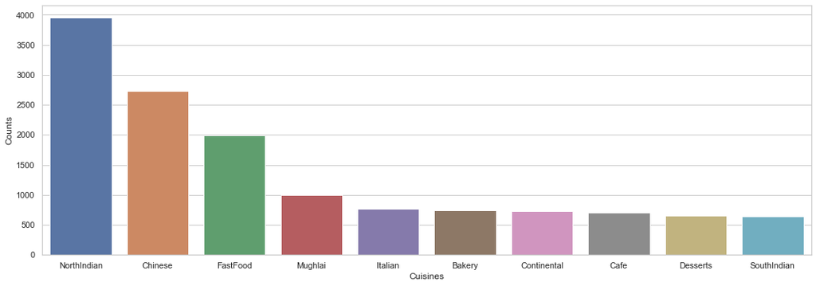

```python
sns.set(style="whitegrid")
f, ax = plt.subplots(figsize=(18, 6))
ax=sns.barplot(x='Cuisines',y='Counts', data=Top_10_cuisines)
```

# North Indian cuisines has the maximum served across cities, followed by Chinese and Fast Food where Many cuisines has only 1 served.

```python
df2 = pd.DataFrame(df, columns=['Restaurant Name','City','Cuisines'])
df2
```

|  | Restaurant Name | City | Cuisines |
| --- | --- | --- | --- |
| 0 | Skye | Jakarta | Italian, Continental |
| 1 | Satoo - Hotel Shangri-La | Jakarta | Asian, Indonesian, Western |
| 2 | Sushi Masa | Jakarta | Sushi, Japanese |
| 3 | 3 Wise Monkeys | Jakarta | Japanese |
| 4 | Avec Moi Restaurant and Bar | Jakarta | French, Western |
| ... | ... | ... | ... |
| 9546 | BMG - All Day Dining | Dehradun | Chinese, North Indian, Fast Food |
| 9547 | Atmosphere Grill Cafe Sheesha | Kanpur | Indian, Chinese, Continental |
| 9548 | UrbanCrave | Kanpur | Cafe, Continental, Desserts, Ice Cream, Italia... |
| 9549 | Deena Chat Bhandar | Varanasi | Street Food |
| 9550 | VNS Live Studio | Varanasi | Chinese, North Indian |

9541 rows × 3 columns

```python
CuisineCount_by_res=pd.DataFrame(df2.groupby('Restaurant Name').Cuisines.count()).reset_index()
CuisineCount_by_res.sort_values(by = 'Cuisines', ascending = False)
```

|  | Restaurant Name | Cuisines |
| --- | --- | --- |
| 1098 | Cafe Coffee Day | 83 |
| 2096 | Domino's Pizza | 79 |
| 6097 | Subway | 63 |
| 2713 | Green Chick Chop | 51 |
| 4069 | McDonald's | 48 |
| ... | ... | ... |
| 2613 | Ghar Ki Handi | 1 |
| 2612 | Ghar Ka Swad | 1 |
| 2610 | Ghar Bistro Cafe | 1 |
| 2609 | Ghalib Kabab Corner | 1 |
| 7435 | Ìàukura€Ùa Sofras€± | 1 |

7436 rows × 2 columns

```python
df.rename(columns={"Average Cost for two":"Average_Cost_for_two"}, inplace= True)
```

```python
Currency_dis = pd.DataFrame(df.groupby('Currency').Average_Cost_for_two.count()).reset_index()
Currency_dis.sort_values(by='Average_Cost_for_two', ascending = False)
```

|  | Currency | Average_Cost_for_two |
| --- | --- | --- |
| 4 | Indian Rupees(Rs.) | 8651 |
| 2 | Dollar($) | 473 |
| 7 | Pounds(å£) | 80 |
| 1 | Brazilian Real(R$) | 60 |
| 3 | Emirati Diram(AED) | 60 |
| 9 | Rand(R) | 60 |
| 6 | NewZealand($) | 40 |
| 11 | Turkish Lira(TL) | 34 |
| 0 | Botswana Pula(P) | 22 |
| 5 | Indonesian Rupiah(IDR) | 21 |
| 8 | Qatari Rial(QR) | 20 |
| 10 | Sri Lankan Rupee(LKR) | 20 |

```python
Cost_per_restaurants = pd.DataFrame(df.groupby('Restaurant Name').Average_Cost_for_two.sum()).reset_index()
Cost_per_restaurants.sort_values(by = 'Average_Cost_for_two', ascending = False)
```

|  | Restaurant Name | Average_Cost_for_two |
| --- | --- | --- |
| 5889 | Skye | 800000 |
| 5586 | Satoo - Hotel Shangri-La | 800000 |
| 6254 | Talaga Sampireun | 600000 |
| 6162 | Sushi Masa | 500000 |
| 41 | 3 Wise Monkeys | 450000 |
| ... | ... | ... |
| 1911 | Deena Chat Bhandar | 0 |
| 6683 | The Latitude - Radisson Blu | 0 |
| 7087 | UrbanCrave | 0 |
| 5401 | Royal Hotel | 0 |
| 7103 | VNS Live Studio | 0 |

7436 rows × 2 columns

```python
df3=pd.DataFrame(df.groupby(['Currency','Restaurant Name']).agg(Count = ('Average_Cost_for_two','sum'))).reset_index()
df3.sort_values(by='Count', ascending = False)
```

|  | Currency | Restaurant Name | Count |
| --- | --- | --- | --- |
| 7211 | Indonesian Rupiah(IDR) | Skye | 800000 |
| 7210 | Indonesian Rupiah(IDR) | Satoo - Hotel Shangri-La | 800000 |
| 7213 | Indonesian Rupiah(IDR) | Talaga Sampireun | 600000 |
| 7212 | Indonesian Rupiah(IDR) | Sushi Masa | 500000 |
| 7199 | Indonesian Rupiah(IDR) | 3 Wise Monkeys | 450000 |
| ... | ... | ... | ... |
| 5682 | Indian Rupees(Rs.) | Sheroes Hangout | 0 |
| 1046 | Indian Rupees(Rs.) | Atmosphere Grill Cafe Sheesha | 0 |
| 6549 | Indian Rupees(Rs.) | The Latitude - Radisson Blu | 0 |
| 427 | Dollar($) | Senor Iguanas | 0 |
| 1819 | Indian Rupees(Rs.) | Chapter 1 Cafe | 0 |

7463 rows × 3 columns

```python
df3.groupby(['Currency'], sort=False)['Count'].max()
```

```
Currency
Botswana Pula(P)            6000
Brazilian Real(R$)           460
Dollar($)                    500
Emirati Diram(AED)           750
Indian Rupees(Rs.)         55300
Indonesian Rupiah(IDR)    800000
NewZealand($)                200
Pounds(å£)                   230
Qatari Rial(QR)              550
Rand(R)                     3210
Sri Lankan Rupee(LKR)       4500
Turkish Lira(TL)             400
Name: Count, dtype: int64
```

Currency wise highest cost across restaurant

```python
Max_cost=df3.groupby('Currency')\
 .apply(lambda group: group[group.Count == group.Count.max()])\
 .reset_index(drop=True)
Max_cost.sort_values(by='Count', ascending = False)
```

|  | Currency | Restaurant Name | Count |
| --- | --- | --- | --- |
| 5 | Indonesian Rupiah(IDR) | Satoo - Hotel Shangri-La | 800000 |
| 6 | Indonesian Rupiah(IDR) | Skye | 800000 |
| 4 | Indian Rupees(Rs.) | Domino's Pizza | 55300 |
| 0 | Botswana Pula(P) | Spiral - Sofitel Philippine Plaza Manila | 6000 |
| 11 | Sri Lankan Rupee(LKR) | The Manhattan Fish Market | 4500 |
| 10 | Rand(R) | Restaurant Mosaic @ The Orient | 3210 |
| 3 | Emirati Diram(AED) | Applebee's | 750 |
| 9 | Qatari Rial(QR) | Vine - The St. Regis | 550 |
| 2 | Dollar($) | Restaurant Andre | 500 |
| 1 | Brazilian Real(R$) | Coco Bambu | 460 |
| 12 | Turkish Lira(TL) | Nusr-Et | 400 |
| 8 | Pounds(å£) | Restaurant Gordon Ramsay | 230 |
| 7 | NewZealand($) | Hippopotamus - Museum Hotel | 200 |

The above table shows the currency wise highest cost accross different restaurants. For example 'Skye' and 'Satoo - Hotel Shangri-La' have the maximum cost with IDR currency, 'Domino's Pizza' has maximum cost with 'Indian Rupees' currency etc.

Rating distribution

```python
df.rename(columns={"Aggregate rating":"Aggregate_rating"}, inplace= True)
```

```python
Rating_count=pd.DataFrame(df.groupby('Aggregate_rating').agg(Count = ('Restaurant Name','count'))).reset_index()
Rating_count.sort_values(by='Aggregate_rating', ascending = False)
```

|  | Aggregate_rating | Count |
| --- | --- | --- |
| 32 | 4.9 | 61 |
| 31 | 4.8 | 25 |
| 30 | 4.7 | 41 |
| 29 | 4.6 | 78 |
| 28 | 4.5 | 95 |
| 27 | 4.4 | 143 |
| 26 | 4.3 | 174 |
| 25 | 4.2 | 221 |
| 24 | 4.1 | 273 |
| 23 | 4.0 | 266 |
| 22 | 3.9 | 332 |
| 21 | 3.8 | 399 |
| 20 | 3.7 | 427 |
| 19 | 3.6 | 458 |
| 18 | 3.5 | 480 |
| 17 | 3.4 | 495 |
| 16 | 3.3 | 483 |
| 15 | 3.2 | 522 |
| 14 | 3.1 | 519 |
| 13 | 3.0 | 468 |
| 12 | 2.9 | 381 |
| 11 | 2.8 | 315 |
| 10 | 2.7 | 250 |
| 9 | 2.6 | 191 |
| 8 | 2.5 | 110 |
| 7 | 2.4 | 87 |
| 6 | 2.3 | 47 |
| 5 | 2.2 | 27 |
| 4 | 2.1 | 15 |
| 3 | 2.0 | 7 |
| 2 | 1.9 | 2 |
| 1 | 1.8 | 1 |
| 0 | 0.0 | 2148 |

We can see in the above table that 61 restaurnat has received the maxium rating of 4.9 while 2148 restaurant has received no rating.

```python
Country_Rating_count=pd.DataFrame(df.groupby(['Country','Aggregate_rating']).agg(Count =
 ('Restaurant Name','count'))).reset_index()
Country_Rating_count.sort_values(by='Aggregate_rating', ascending = False)
```

|  | Country | Aggregate_rating | Count |
| --- | --- | --- | --- |
| 221 | United States | 4.9 | 14 |
| 92 | New Zealand | 4.9 | 2 |
| 139 | South Africa | 4.9 | 3 |
| 151 | Sri Lanka | 4.9 | 1 |
| 32 | Brazil | 4.9 | 3 |
| ... | ... | ... | ... |
| 38 | India | 1.8 | 1 |
| 200 | United States | 0.0 | 3 |
| 12 | Brazil | 0.0 | 5 |
| 180 | United Kingdom | 0.0 | 1 |
| 37 | India | 0.0 | 2139 |

222 rows × 3 columns

```python
Country_wise_top_rating=pd.DataFrame(Country_Rating_count[Country_Rating_count.Aggregate_rating >= 4.9]).reset_index()
Country_wise_top_rating.sort_values(by='Count', ascending = False)
```

|  | index | Country | Aggregate_rating | Count |
| --- | --- | --- | --- | --- |
| 1 | 69 | India | 4.9 | 19 |
| 11 | 221 | United States | 4.9 | 14 |
| 2 | 79 | Indonesia | 4.9 | 4 |
| 9 | 179 | UAE | 4.9 | 4 |
| 10 | 199 | United Kingdom | 4.9 | 4 |
| 0 | 32 | Brazil | 4.9 | 3 |
| 4 | 101 | Phillipines | 4.9 | 3 |
| 6 | 139 | South Africa | 4.9 | 3 |
| 8 | 163 | Turkey | 4.9 | 3 |
| 3 | 92 | New Zealand | 4.9 | 2 |
| 5 | 114 | Qatar | 4.9 | 1 |
| 7 | 151 | Sri Lanka | 4.9 | 1 |

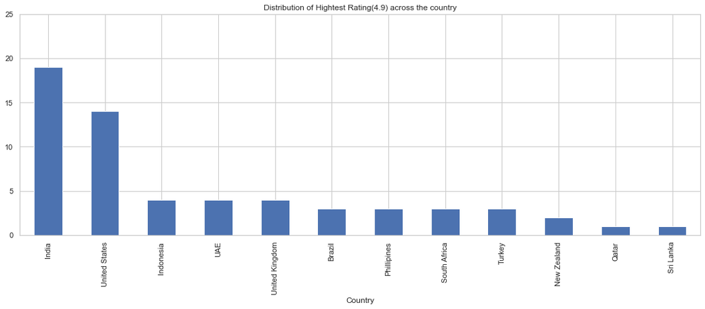

```python
Country_wise_top_rating.sort_values(by='Count', ascending = False).plot(kind= 'bar', x = "Country", y= "Count", legend = False,
                                                                        title= "Distribution of Hightest Rating(4.9) across the country", figsize = (18,6))
plt.ylim([0,25]);
```

Rating distribution basis Rating Type (Excellent, Very Good, Good, Average, Poor and Not Rated)

```python
df.rename(columns={"Rating text":"Rating_Text"}, inplace= True)
```

```python
RatingType_count=pd.DataFrame(df.groupby('Rating_Text').agg(Count = ('Restaurant Name','count'))).reset_index()
RatingType_count
```

|  | Rating_Text | Count |
| --- | --- | --- |
| 0 | Average | 3734 |
| 1 | Excellent | 300 |
| 2 | Good | 2096 |
| 3 | Not rated | 2148 |
| 4 | Poor | 186 |
| 5 | Very Good | 1077 |

```python
Country_RatingType_count=pd.DataFrame(df.groupby(['Country','Rating_Text']).agg(Count =
 ('Restaurant Name','count'))).reset_index()
Country_RatingType_count
```

|  | Country | Rating_Text | Count |
| --- | --- | --- | --- |
| 0 | Australia | Average | 4 |
| 1 | Australia | Excellent | 1 |
| 2 | Australia | Good | 13 |
| 3 | Australia | Poor | 1 |
| 4 | Australia | Very Good | 5 |
| ... | ... | ... | ... |
| 61 | United States | Excellent | 67 |
| 62 | United States | Good | 155 |
| 63 | United States | Not rated | 3 |
| 64 | United States | Poor | 2 |
| 65 | United States | Very Good | 178 |

66 rows × 3 columns

```python
Country_wise_ratingType=pd.DataFrame(Country_RatingType_count[Country_RatingType_count.Rating_Text =='Excellent']).reset_index()
Country_wise_ratingType.sort_values(by='Count', ascending = False)
```

|  | index | Country | Rating_Text | Count |
| --- | --- | --- | --- | --- |
| 2 | 14 | India | Excellent | 116 |
| 12 | 61 | United States | Excellent | 67 |
| 11 | 56 | United Kingdom | Excellent | 23 |
| 10 | 51 | UAE | Excellent | 18 |
| 1 | 6 | Brazil | Excellent | 16 |
| 4 | 23 | New Zealand | Excellent | 12 |
| 5 | 27 | Phillipines | Excellent | 12 |
| 7 | 38 | South Africa | Excellent | 12 |
| 9 | 47 | Turkey | Excellent | 10 |
| 3 | 20 | Indonesia | Excellent | 7 |
| 6 | 31 | Qatar | Excellent | 4 |
| 8 | 42 | Sri Lanka | Excellent | 2 |
| 0 | 1 | Australia | Excellent | 1 |

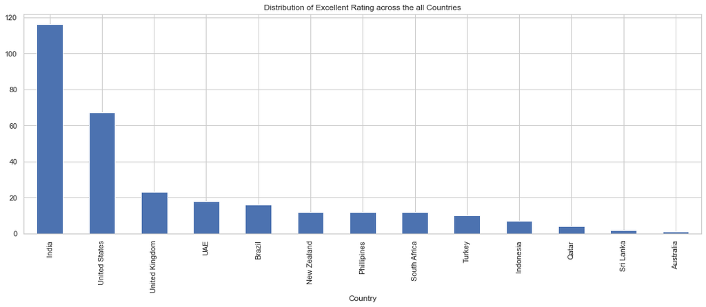

```python
Country_wise_ratingType.sort_values(by= 'Count',ascending= False).plot(kind = 'bar', x="Country", y='Count', legend = False,
                                                                       title = "Distribution of Excellent Rating across the all Countries", figsize= (18,6));
```

In the Above Chart we can see that India has the maximum restaurant with Excellent Rating and Australia has the Minimum

```python
Rating_corr=df[['Restaurant ID','Restaurant Name','Country','City','Aggregate_rating','Average_Cost_for_two','Votes',
 'Price range','Has Table booking','Has Online delivery']]
```

```python
dummy = ['Has Table booking','Has Online delivery']
Rating_corr = pd.get_dummies(Rating_corr,columns=dummy,drop_first=True)
Rating_corr = Rating_corr.merge(CuisineCount_by_res,left_on='Restaurant Name',right_on='Restaurant Name',how='left')
Rating_corr.head()
```

|  | Restaurant ID | Restaurant Name | Country | City | Aggregate_rating | Average_Cost_for_two | Votes | Price range | Has Table booking_Yes | Has Online delivery_Yes | Cuisines |
| --- | --- | --- | --- | --- | --- | --- | --- | --- | --- | --- | --- |
| 0 | 7402935 | Skye | Indonesia | Jakarta | 4.1 | 800000 | 1498 | 3 | 0 | 0 | 1 |
| 1 | 7410290 | Satoo - Hotel Shangri-La | Indonesia | Jakarta | 4.6 | 800000 | 873 | 3 | 0 | 0 | 1 |
| 2 | 7420899 | Sushi Masa | Indonesia | Jakarta | 4.9 | 500000 | 605 | 3 | 0 | 0 | 1 |
| 3 | 7421967 | 3 Wise Monkeys | Indonesia | Jakarta | 4.2 | 450000 | 395 | 3 | 0 | 0 | 1 |
| 4 | 7422489 | Avec Moi Restaurant and Bar | Indonesia | Jakarta | 4.3 | 350000 | 243 | 3 | 0 | 0 | 1 |

Correlation between "Rating" and "Average cost for two"

|  | Average_Cost_for_two | Aggregate_rating |
| --- | --- | --- |
| Average_Cost_for_two | 1.000000 | 0.051869 |
| Aggregate_rating | 0.051869 | 1.000000 |

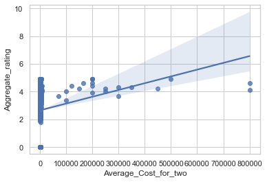

```python
sns.regplot(x='Average_Cost_for_two',y='Aggregate_rating',data=Rating_corr)
Rating_corr[["Average_Cost_for_two", "Aggregate_rating"]].corr()
```

The above chart shows weak positive correlation between average cost of tow and aggregate rating

Correlation between "Rating" and "Has Table Booking"

|  | Has Table booking_Yes | Aggregate_rating |
| --- | --- | --- |
| Has Table booking_Yes | 1.000000 | 0.190398 |
| Aggregate_rating | 0.190398 | 1.000000 |

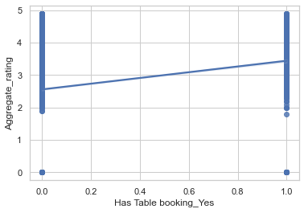

```python
sns.regplot(x='Has Table booking_Yes',y='Aggregate_rating',data=Rating_corr)
Rating_corr[['Has Table booking_Yes','Aggregate_rating']].corr()
```

Correlation between "Rating" and "Price Range"

|  | Price range | Aggregate_rating |
| --- | --- | --- |
| Price range | 1.000000 | 0.438286 |
| Aggregate_rating | 0.438286 | 1.000000 |

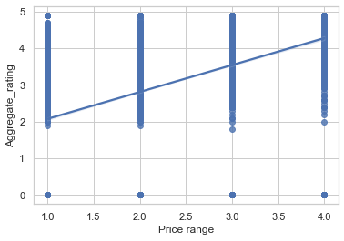

```python
sns.regplot(x='Price range',y='Aggregate_rating',data=Rating_corr)
Rating_corr[['Price range','Aggregate_rating']].corr()
```

Correlation between "Rating" and "Votes"

|  | Votes | Aggregate_rating |
| --- | --- | --- |
| Votes | 1.000000 | 0.313381 |
| Aggregate_rating | 0.313381 | 1.000000 |

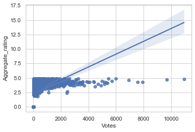

```python
sns.regplot(x = 'Votes', y= 'Aggregate_rating',data= Rating_corr)
Rating_corr[['Votes', 'Aggregate_rating']].corr()
```

Votes and rating also has a positive relation this is also a major factor for deciding the rating.

Correlation between "Rating" and "Cuisines Count"

|  | Cuisines | Aggregate_rating |
| --- | --- | --- |
| Cuisines | 1.000000 | 0.021332 |
| Aggregate_rating | 0.021332 | 1.000000 |

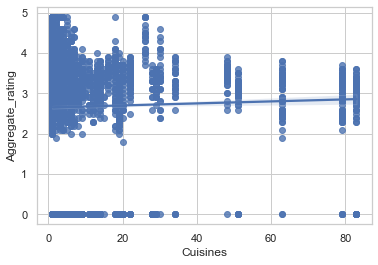

```python
sns.regplot(x='Cuisines',y='Aggregate_rating',data=Rating_corr)
Rating_corr[['Cuisines','Aggregate_rating']].corr()
```

Cuisines and Rating has the weakest correlation with each other, hence this cannot be the deciding factor for rating.